# Glucocorticoid response in human airway smooth muscle cells: RNA-seq differential expression

Jennifer Hsieh, PhD

2026-10-10

*This report summarises outputs generated by the scripts in `R/`. Re-run `Rscript R/run_all.R` to regenerate every number and figure.*

## 1. Question

Which genes respond to the synthetic glucocorticoid **dexamethasone** in primary human airway smooth muscle (ASM) cells, and does the response recover known glucocorticoid biology? Glucocorticoids are the mainstay anti-inflammatory therapy in asthma, and ASM is one of their target tissues.

## 2. Data

- **Study:** Himes BE et al. (2014) *RNA-Seq transcriptome profiling identifies CRISPLD2 as a glucocorticoid responsive gene that modulates cytokine function in airway smooth muscle cells.* PLoS ONE 9(6): e99625. doi:10.1371/journal.pone.0099625
- **GEO accession:** GSE52778, 16 samples: four primary ASM donor cell lines, each untreated, 1 µM dexamethasone, 1 µM albuterol, or both (18 h).
- **Counts:** NCBI GEO RNA-seq pipeline raw gene counts (GRCh38.p13, NCBI Gene IDs), 16,802 genes tested after filtering in the primary comparison.
- **Annotation:** `org.Hs.eg.db` (Entrez ID to symbol, name and gene type).

## 3. Quality control (all 16 samples)

Assigned reads per library ranged from 19.2 to 39.1 million, with 15,791-17,116 genes at ≥ 10 counts. DESeq2 median-of-ratios size factors ranged from 0.71 to 1.33. No library was an outlier on depth or detected genes.

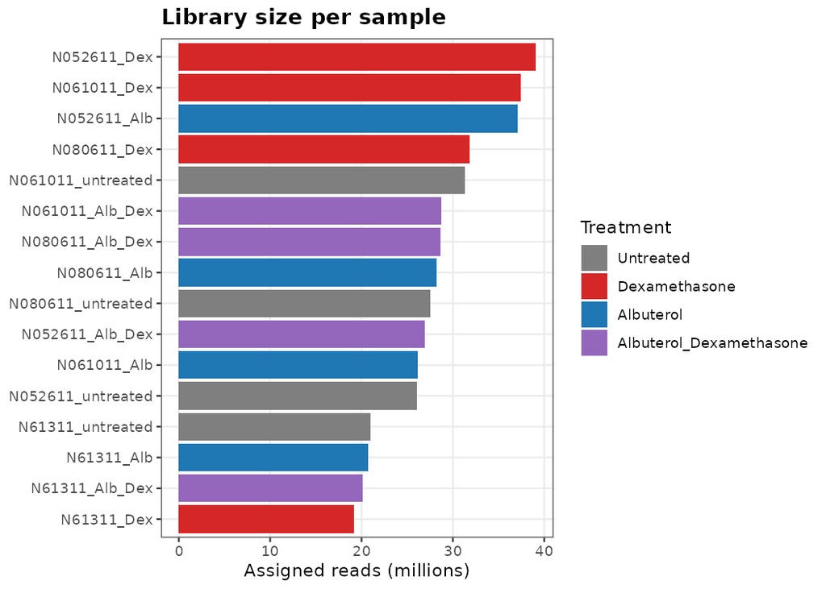

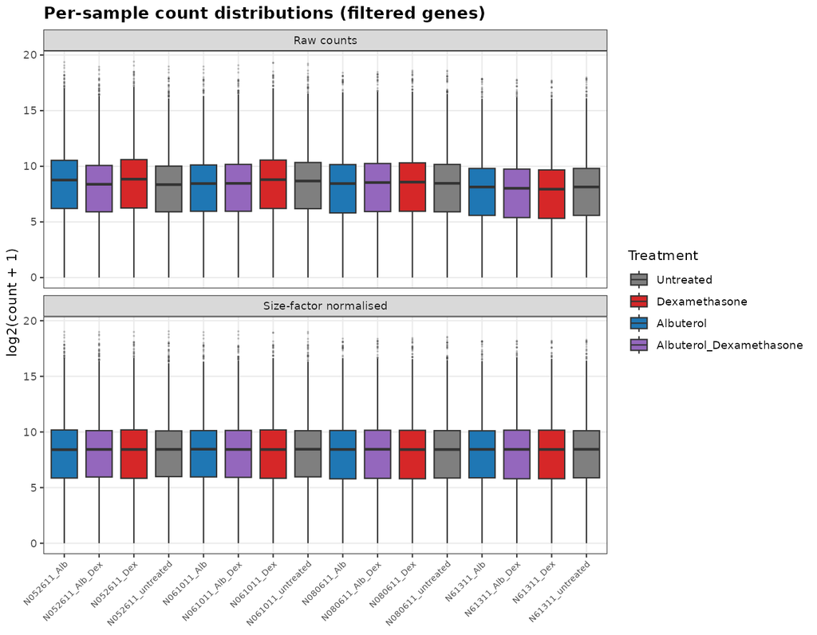

PCA on the variance-stabilised data (top 500 variable genes) separates samples into two groups along PC1 (40.3% of variance), while PC2 (27.5%) and PC3 largely reflect the donor cell line.

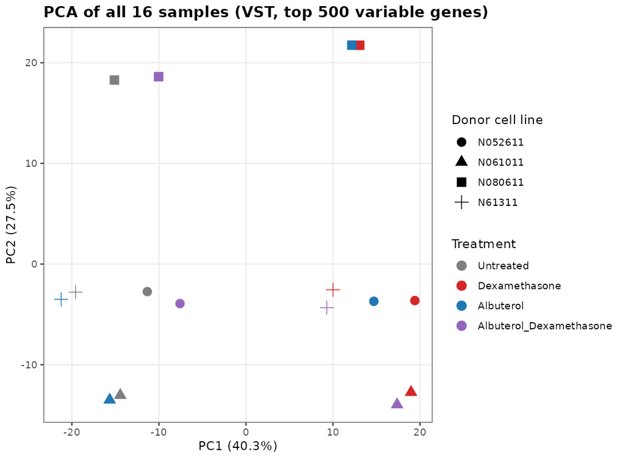

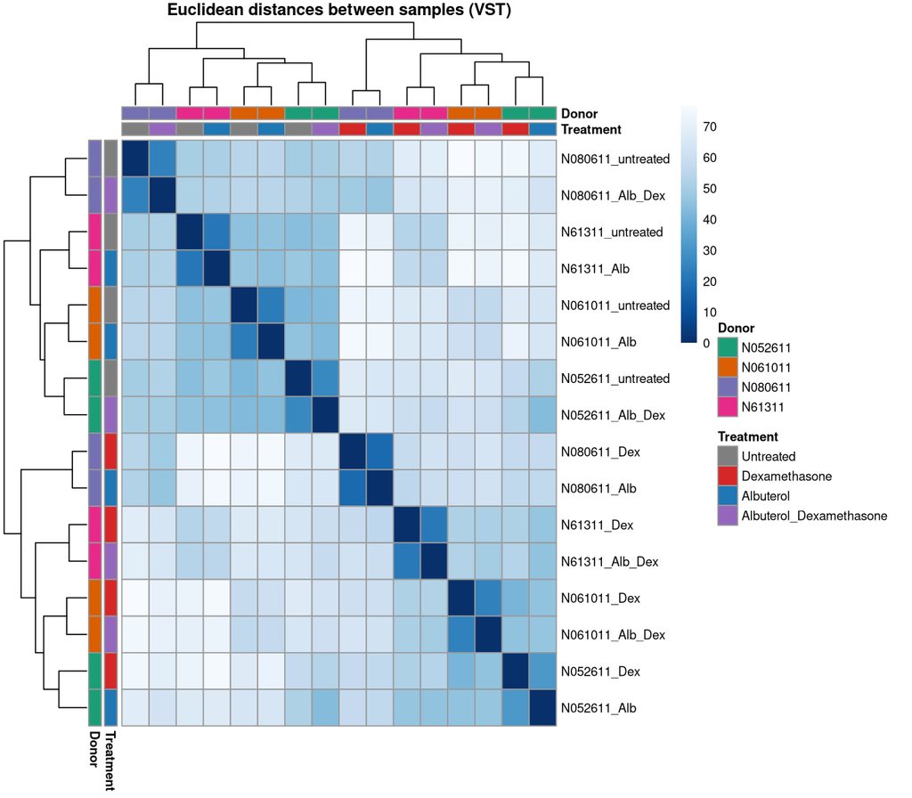

### Metadata check

PC1 should correspond to glucocorticoid exposure. All four untreated and all four dexamethasone samples fall where expected, but for donors **N052611** and **N080611** the sample annotated “Albuterol” clusters with dexamethasone-treated samples and the sample annotated “Albuterol_Dexamethasone” clusters with untreated samples. A score built from seven canonical glucocorticoid targets confirms this:

| Sample | Donor | Annotated treatment | GC score |
| --- | --- | --- | --- |
| N61311_Alb | N61311 | Albuterol | -1.78 |
| N61311_Alb_Dex | N61311 | Albuterol_Dexamethasone | 1.87 |
| N052611_Alb | N052611 | Albuterol | 1.64 |
| N052611_Alb_Dex | N052611 | Albuterol_Dexamethasone | -0.46 |
| N080611_Alb | N080611 | Albuterol | 0.77 |
| N080611_Alb_Dex | N080611 | Albuterol_Dexamethasone | -1.14 |
| N061011_Alb | N061011 | Albuterol | -1.65 |
| N061011_Alb_Dex | N061011 | Albuterol_Dexamethasone | 1.95 |

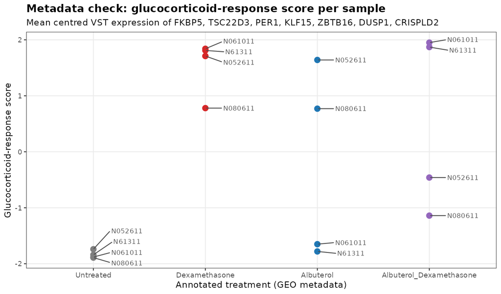

The pattern is consistent with swapped or mis-annotated albuterol samples in those two donors (the “Albuterol_Dexamethasone” samples also show a weaker, intermediate glucocorticoid signature). This analysis does not try to resolve it. **The albuterol arms are excluded**, and the primary comparison uses only the untreated and dexamethasone samples, whose labels are internally consistent. These are the same eight samples distributed in the Bioconductor `airway` package.

## 4. Differential expression: dexamethasone vs untreated

**Design:** `~ cell_line + treatment` (paired by donor), 8 samples. Genes were kept with ≥ 10 counts in ≥ 4 samples. DESeq2 Wald test, Benjamini-Hochberg FDR. Log2 fold changes were shrunk with the `normal` prior for the MA plot and ranking. edgeR (quasi-likelihood F-test) and limma-voom were fitted with the same design as cross-checks.

| Metric | Value |
| --- | --- |
| Genes tested | 16,802 |
| DESeq2 FDR < 0.05 | 4,743 |
| DESeq2 FDR < 0.05, up in Dex | 2,557 |
| DESeq2 FDR < 0.05, down in Dex | 2,186 |
| DESeq2 FDR < 0.05 and \|log2FC\| > 1 | 1,071 |
| of which up (log2FC > 1) | 539 |
| of which down (log2FC < -1) | 532 |
| edgeR QL FDR < 0.05 | 5,531 |
| limma-voom FDR < 0.05 | 5,596 |
| Significant in all three methods | 4,628 |
| Spearman r of log2FC, DESeq2 vs edgeR | 0.998 |
| Spearman r of log2FC, DESeq2 vs limma-voom | 0.998 |

In the 8-sample PCA, PC1 explains about half the variance and separates treatment; donor accounts for most of the rest.

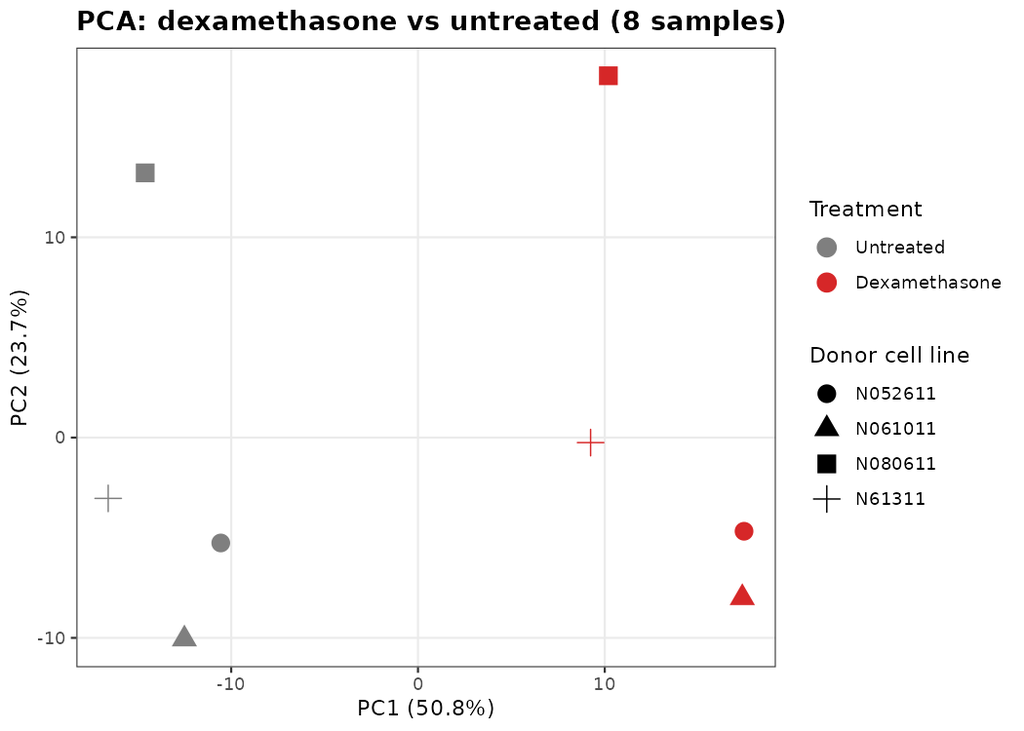

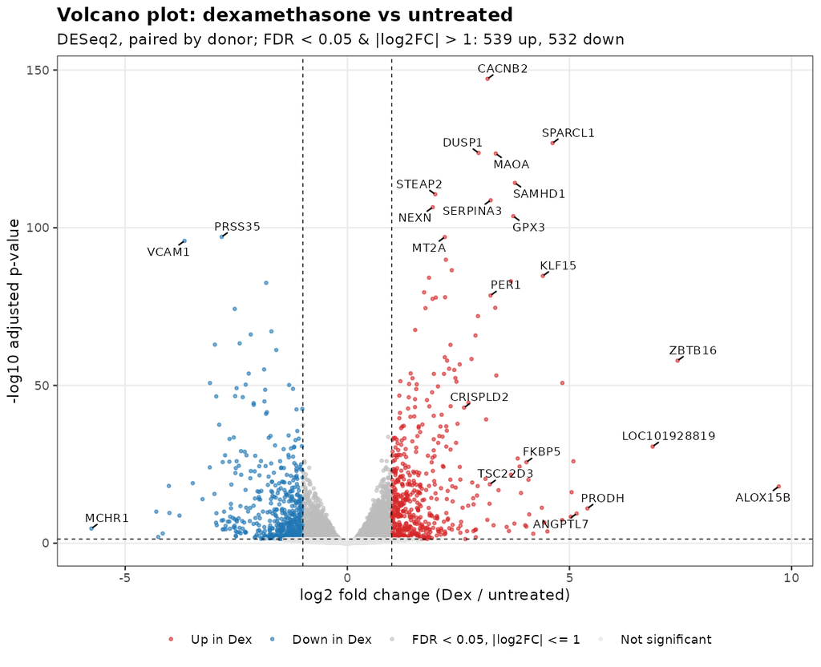

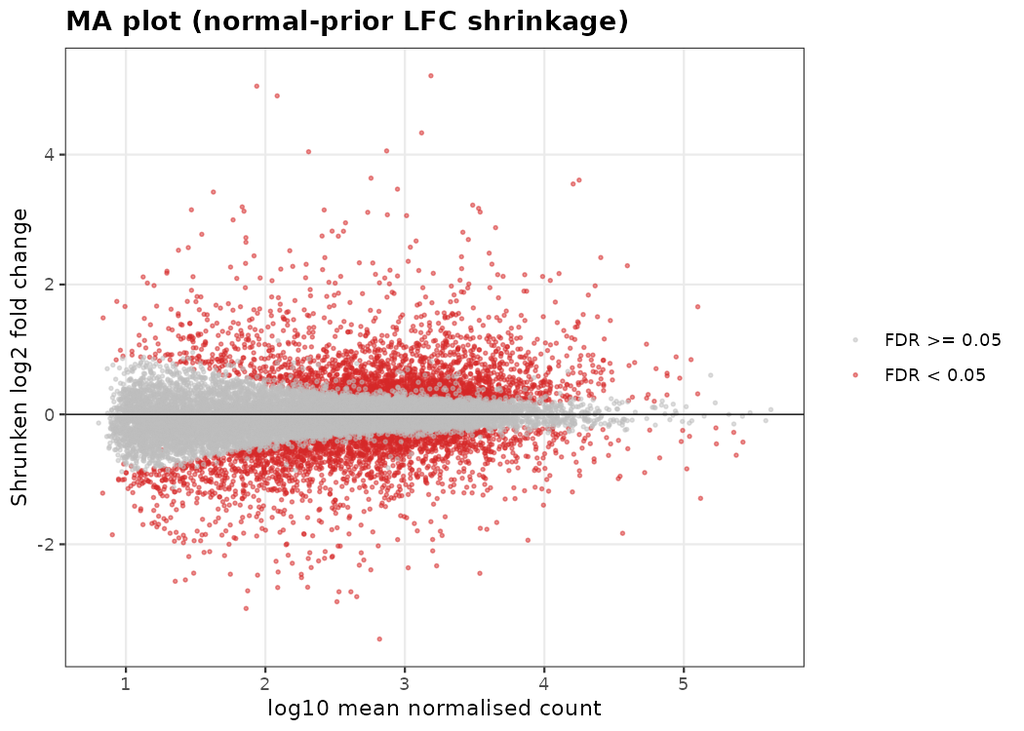

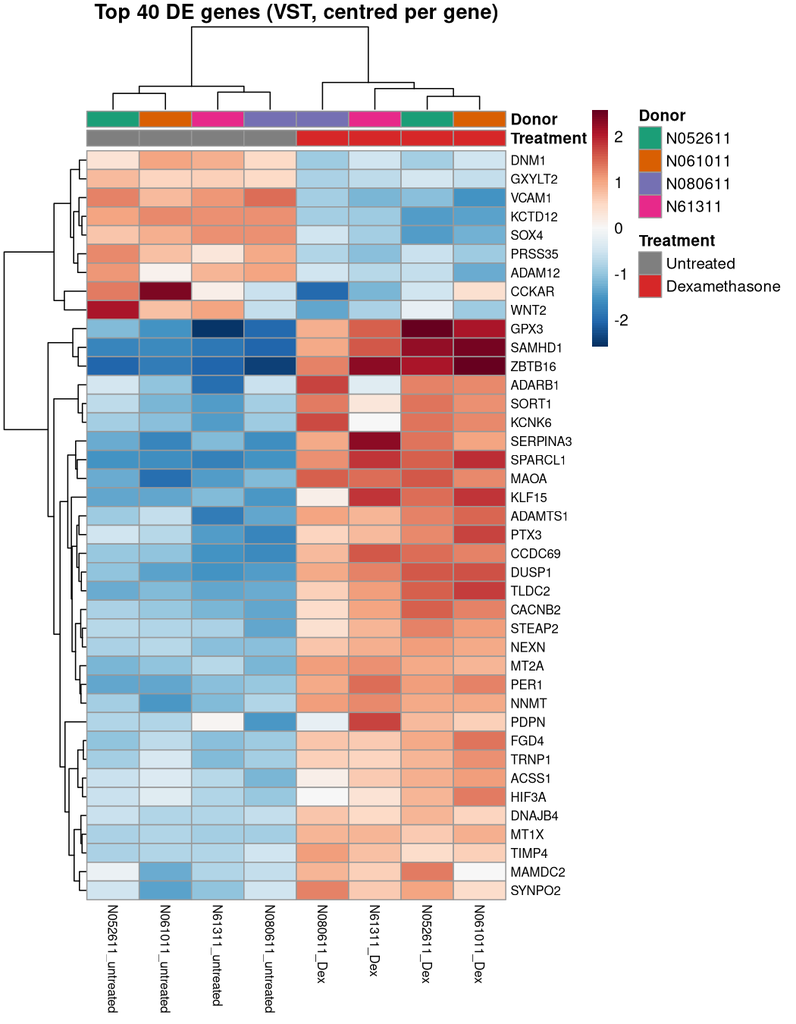

### Top 15 genes by adjusted p-value

| Gene | Description | Mean count | log2FC | FDR |
| --- | --- | --- | --- | --- |
| CACNB2 | calcium voltage-gated channel auxiliary subunit beta 2 | 749 | 3.16 | 6.0e-148 |
| SPARCL1 | SPARC like 1 | 1318 | 4.62 | 1.4e-127 |
| DUSP1 | dual specificity phosphatase 1 | 4469 | 2.95 | 1.9e-124 |
| MAOA | monoamine oxidase A | 3063 | 3.34 | 3.0e-124 |
| SAMHD1 | SAM and HD domain containing deoxynucleoside triphosphate triphosphohydrolase 1 | 17751 | 3.77 | 6.1e-115 |
| STEAP2 | STEAP2 metalloreductase | 4068 | 1.98 | 2.5e-111 |
| SERPINA3 | serpin family A member 3 | 3465 | 3.23 | 1.9e-109 |
| NEXN | nexilin F-actin binding protein | 7460 | 1.92 | 3.1e-107 |
| GPX3 | glutathione peroxidase 3 | 16078 | 3.74 | 2.1e-104 |
| PRSS35 | serine protease 35 | 410 | -2.83 | 7.9e-98 |
| MT2A | metallothionein 2A | 4627 | 2.19 | 8.8e-98 |
| VCAM1 | vascular cell adhesion molecule 1 | 658 | -3.66 | 1.5e-96 |
| FGD4 | FYVE, RhoGEF and PH domain containing 4 | 1598 | 2.22 | 1.4e-90 |
| ADAMTS1 | ADAM metallopeptidase with thrombospondin type 1 motif 1 | 39345 | 2.35 | 2.9e-87 |
| KLF15 | KLF transcription factor 15 | 740 | 4.40 | 1.8e-85 |

### Positive controls

| Gene | log2FC | Fold change | FDR |
| --- | --- | --- | --- |
| FKBP5 | 4.03 | 16.3 | 2.1e-26 |
| TSC22D3 | 3.21 | 9.2 | 2.2e-19 |
| PER1 | 3.22 | 9.3 | 3.0e-79 |
| KLF15 | 4.40 | 21.1 | 1.8e-85 |
| ZBTB16 | 7.43 | 172.7 | 1.4e-58 |
| DUSP1 | 2.95 | 7.8 | 1.9e-124 |
| CRISPLD2 | 2.63 | 6.2 | 1.1e-43 |

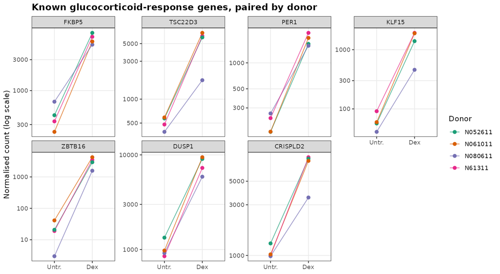

Donor N080611 shows the same direction of change for every marker but a smaller magnitude than the other three donors, which is visible also in its intermediate glucocorticoid score.

### Method concordance

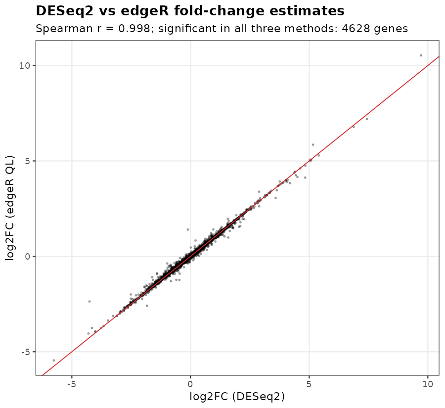

## 5. Pathway-level view (GO biological process)

Over-representation analysis with `limma::goana` used genes at FDR < 0.05 and |log2FC| > 1, against all tested genes as the background, and was restricted for display to gene sets of 15-500 genes.

| GO term | Direction | DE genes | Set size | FDR |
| --- | --- | --- | --- | --- |
| regulation of system process | Up | 33 | 359 | 3.4e-05 |
| muscle system process | Up | 29 | 303 | 7.5e-05 |
| extracellular matrix organization | Up | 26 | 252 | 7.5e-05 |
| extracellular structure organization | Up | 26 | 252 | 7.5e-05 |
| external encapsulating structure organization | Up | 26 | 254 | 8.5e-05 |
| cell-substrate adhesion | Up | 28 | 289 | 8.9e-05 |
| cellular response to hormone stimulus | Up | 37 | 484 | 3.3e-04 |
| negative regulation of cell motility | Up | 24 | 243 | 3.4e-04 |
| blood vessel morphogenesis | Up | 37 | 494 | 4.7e-04 |
| negative regulation of cell migration | Up | 23 | 234 | 5.5e-04 |
| plasma membrane bounded cell projection morphogenesis | Down | 42 | 498 | 4.7e-06 |
| neuron projection morphogenesis | Down | 41 | 482 | 5.3e-06 |
| blood circulation | Down | 33 | 343 | 7.1e-06 |
| regulation of blood circulation | Down | 22 | 170 | 1.0e-05 |
| circulatory system process | Down | 36 | 409 | 1.4e-05 |
| G protein-coupled receptor signaling pathway | Down | 37 | 431 | 1.7e-05 |
| cell morphogenesis involved in neuron differentiation | Down | 37 | 436 | 2.2e-05 |
| axonogenesis | Down | 31 | 330 | 2.7e-05 |
| regulation of nervous system development | Down | 31 | 333 | 3.1e-05 |
| axon guidance | Down | 20 | 154 | 3.2e-05 |

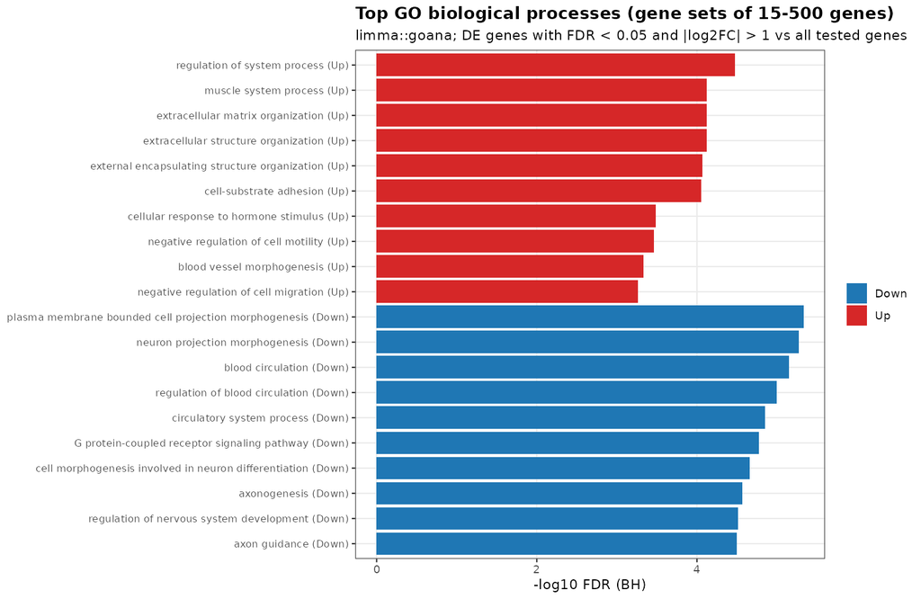

## 6. Interpretation

- Dexamethasone produces a large, highly reproducible transcriptional response in ASM cells: 4,743 genes at FDR < 0.05, of which 1,071 change more than two-fold, roughly balanced between induction and repression.
- The strongest hits recover canonical glucocorticoid-receptor targets: **FKBP5** (GR co-chaperone and negative-feedback regulator), **TSC22D3**/GILZ and **DUSP1**/MKP-1 (both key mediators of glucocorticoid anti-inflammatory action), **PER1**, **KLF15** and **ZBTB16**. **CRISPLD2**, the gene highlighted by the original study, is induced about 6.2-fold, which reproduces the published finding.
- Repressed genes include the adhesion molecule **VCAM1** and modest decreases in the inflammatory cytokine genes **IL6** (log2FC -0.81, FDR 0.015) and **CCL2** (log2FC -0.54, FDR 0.038), consistent with the anti-inflammatory profile of glucocorticoids. Up-regulated genes are enriched for extracellular-matrix organisation, cell-substrate adhesion and response to hormone stimulus, and down-regulated genes for GPCR signalling and cell-projection morphogenesis terms. These suggest effects on ASM structure and signalling beyond inflammation.
- DESeq2, edgeR and limma-voom agree closely (Spearman ρ ≈ 0.998 for fold changes; 4,628 genes significant in all three), so the conclusions do not depend on the choice of method.

## 7. Limitations

- n = 4 donors per group. The paired design controls donor effects, but inter-individual variation in response (e.g. N080611) is only partly captured.
- A single dose and time point (18 h). Primary vs secondary response genes cannot be separated.
- GO over-representation depends on the significance and fold-change cut-offs and on GO annotation bias; it is hypothesis-generating.
- The albuterol and combination arms were not analysed because of the metadata inconsistency described in Section 3.